# Anscombe’s quartet

Krzysztof Stawarz

2023-01-03

### Zadanie 1.

Wyświetl zbiór anscombe z poziomu wiersza poleceń RStudio (wbudowany obiekt).  
Możesz wykorzystać funkcję print().

```r
data = anscombe
data
```

```
##    x1 x2 x3 x4    y1   y2    y3    y4
## 1  10 10 10  8  8.04 9.14  7.46  6.58
## 2   8  8  8  8  6.95 8.14  6.77  5.76
## 3  13 13 13  8  7.58 8.74 12.74  7.71
## 4   9  9  9  8  8.81 8.77  7.11  8.84
## 5  11 11 11  8  8.33 9.26  7.81  8.47
## 6  14 14 14  8  9.96 8.10  8.84  7.04
## 7   6  6  6  8  7.24 6.13  6.08  5.25
## 8   4  4  4 19  4.26 3.10  5.39 12.50
## 9  12 12 12  8 10.84 9.13  8.15  5.56
## 10  7  7  7  8  4.82 7.26  6.42  7.91
## 11  5  5  5  8  5.68 4.74  5.73  6.89
```

### Zadanie 2.

Podziel dane na cztery ramki danych: ans1, …, ans4 z kolumnami x oraz y.  
Zbuduj ramki danych z wykorzystaniem data.frame()

```r
ans1 = data.frame('x' = data[,1], 'y' = data[, 5])
ans2 = data.frame('x' = data[,2], 'y' = data[, 6])
ans3 = data.frame('x' = data[,3], 'y' = data[, 7])
ans4 = data.frame('x' = data[,4], 'y' = data[, 8])

# zrobiłem z nich liste w celu wyświetlenia
ans_list = list('ans1' = ans1, 'ans2' = ans2, 'ans3' = ans3, 'ans4' = ans4)

ans_list
```

```
## $ans1
##     x     y
## 1  10  8.04
## 2   8  6.95
## 3  13  7.58
## 4   9  8.81
## 5  11  8.33
## 6  14  9.96
## 7   6  7.24
## 8   4  4.26
## 9  12 10.84
## 10  7  4.82
## 11  5  5.68
##
## $ans2
```

[output cut: 40 more lines]

### Zadanie 3.

Wyznacz średnią (z wykorzystaniem wbudowanej funkcji) z każdej zmiennej x oraz y.  
Spróbuj także wyznaczyć średnią z całego zbioru danych (wykorzystaj do tego celu jedną z funkcji, np. sapply()).  
Skomentuj uzyskane wyniki.

```r
mean1 = apply(ans1, 2, mean)
mean2 = apply(ans2, 2, mean)
mean3 = apply(ans3, 2, mean)
mean4 = apply(ans4, 2, mean)

mean_list = list('mean_ans1' = mean1, 'mean_ans2' = mean2, 'mean_ans3' = mean3, 'mean_ans4' = mean4)

mean_list
```

```
## $mean_ans1
##        x        y
## 9.000000 7.500909
##
## $mean_ans2
##        x        y
## 9.000000 7.500909
##
## $mean_ans3
##   x   y
## 9.0 7.5
##
## $mean_ans4
##        x        y
## 9.000000 7.500909
```

lub po prostu:

```r
sapply(data, mean)
```

```
##       x1       x2       x3       x4       y1       y2       y3       y4
## 9.000000 9.000000 9.000000 9.000000 7.500909 7.500909 7.500000 7.500909
```

Jak widać, wszystkie średnie z każdej zmiennej x są identyczne. Jedna średnia zmiennej y w ans3 z jakiegoś powodu jest różna od pozostałych o 9/10000.  
Spróbuj także wyznaczyć średnią z całego zbioru danych (wykorzystaj do tego celu jedną z funkcji, np. sapply()).

```r
data_matrix = data.matrix(data)
mean(data_matrix)
```

```
## [1] 8.250341
```

Osobiście nie mam pojęcia jak używać funkcji sapply(), więć przerzuciłem sobie ramkę na macierz, gdyż na numerycznej macierzy bajecznie wykonuje się funckje. Wykorzystałem **data.matrix()**.

### Zadanie 4.

Wyznacz odchylenie standardowe (z wykorzystaniem wbudowanej funkcji) z każdej zmiennej x oraz y.

```r
sd1 = apply(ans1, 2, sd)
sd2 = apply(ans2, 2, sd)
sd3 = apply(ans3, 2, sd)
sd4 = apply(ans4, 2, sd)

sd_list = list('sd_ans1' = sd1, 'sd_ans2' = sd2, 'sd_ans3' = sd3, 'sd_ans4' = sd4)

sd_list
```

```
## $sd_ans1
##        x        y
## 3.316625 2.031568
##
## $sd_ans2
##        x        y
## 3.316625 2.031657
##
## $sd_ans3
##        x        y
## 3.316625 2.030424
##
## $sd_ans4
##        x        y
## 3.316625 2.030579
```

lub po prostu:

```r
sapply(data, sd)
```

```
##       x1       x2       x3       x4       y1       y2       y3       y4
## 3.316625 3.316625 3.316625 3.316625 2.031568 2.031657 2.030424 2.030579
```

### Zadanie 5.

Wykorzystaj funkcję knitr::kable(), aby wyświetlić uzyskane wartości (z zadana 4). Skomentuj uzyskane wartości.

```r
library('kableExtra')

knitr::kable(sd1, 'html', col.names="odchylenie standardowe") %>% kable_styling(full_width = F)
```

|  | odchylenie standardowe |
| --- | --- |
| x | 3.316625 |
| y | 2.031568 |

```r
knitr::kable(sd2, 'html', col.names="odchylenie standardowe") %>% kable_styling(full_width = F)
```

|  | odchylenie standardowe |
| --- | --- |
| x | 3.316625 |
| y | 2.031657 |

```r
knitr::kable(sd3, 'html', col.names="odchylenie standardowe") %>% kable_styling(full_width = F)
```

|  | odchylenie standardowe |
| --- | --- |
| x | 3.316625 |
| y | 2.030424 |

```r
knitr::kable(sd4, 'html', col.names="odchylenie standardowe") %>% kable_styling(full_width = F)
```

[output not shown]

Wartości odchyleń standardowych są do siebie bardzo zbliżone. Są praktycznie identyczne do trzeciego miejsca znaczącego.

### Zadanie 6.

Dla każdego zestawu danych dopasuj(-my) prosty model regresji liniowej.

```r
# przygotowuje potrzebne funkcje
print_line_eq <- function(obj) {
  a = obj$coefficients[2]
  b = obj$coefficients[1]
  cat('Równanie prostej: y = ', a, 'x + ', b, sep = "")
}

fit_models <- function(ans) {
  f <- lm(y~x, data=ans)
  plot(ans$x, ans$y) # wykres
  abline(f, col="red") # linia regresji
  print_line_eq(f) # rownanie prostej
}
```

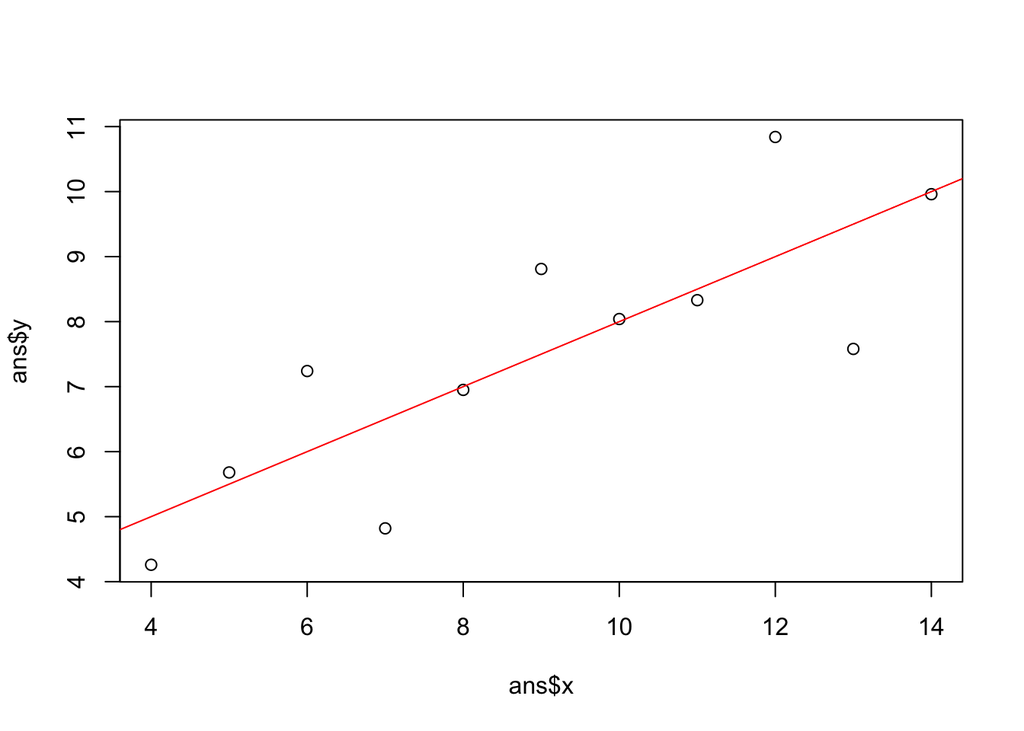

```
## Równanie prostej: y = 0.5000909x + 3.000091
```

```r
# wywołąnie
fit_models(ans1)
```

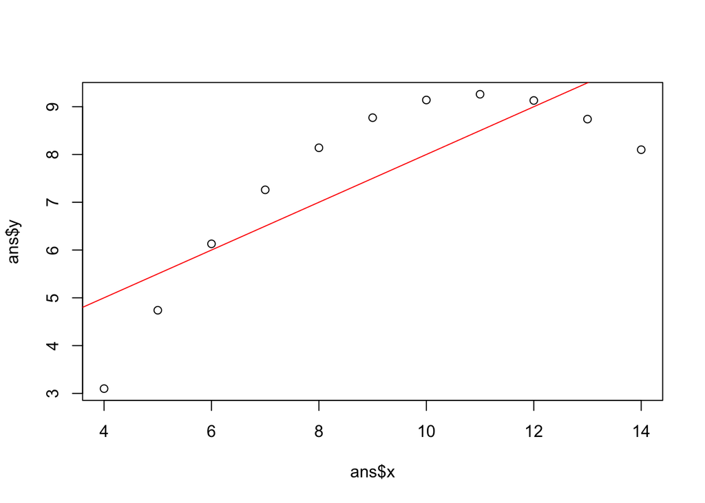

```
## Równanie prostej: y = 0.5x + 3.000909
```

```r
fit_models(ans2)
```

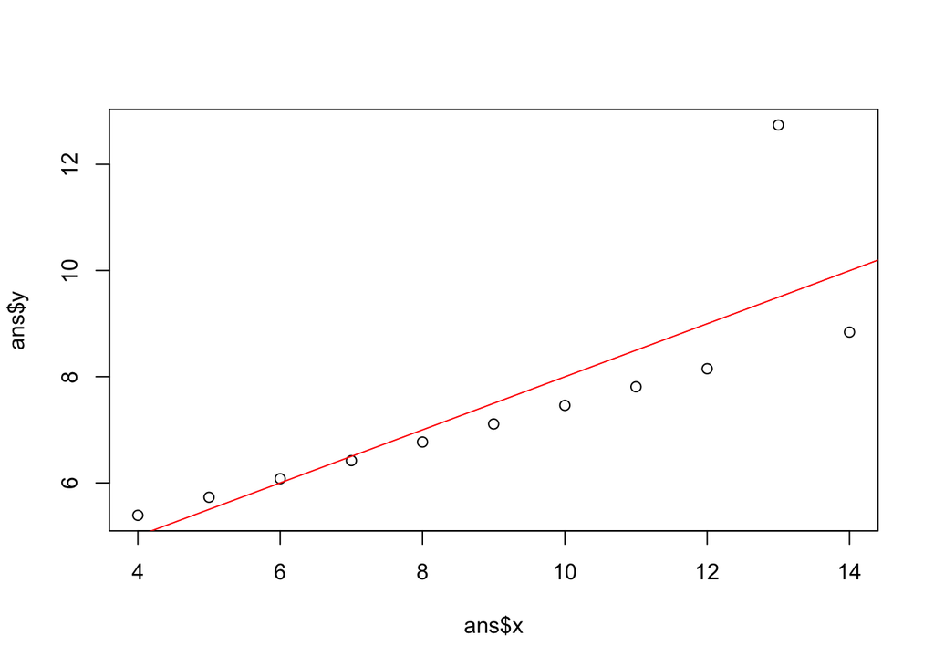

```
## Równanie prostej: y = 0.4997273x + 3.002455
```

```r
fit_models(ans3)
```

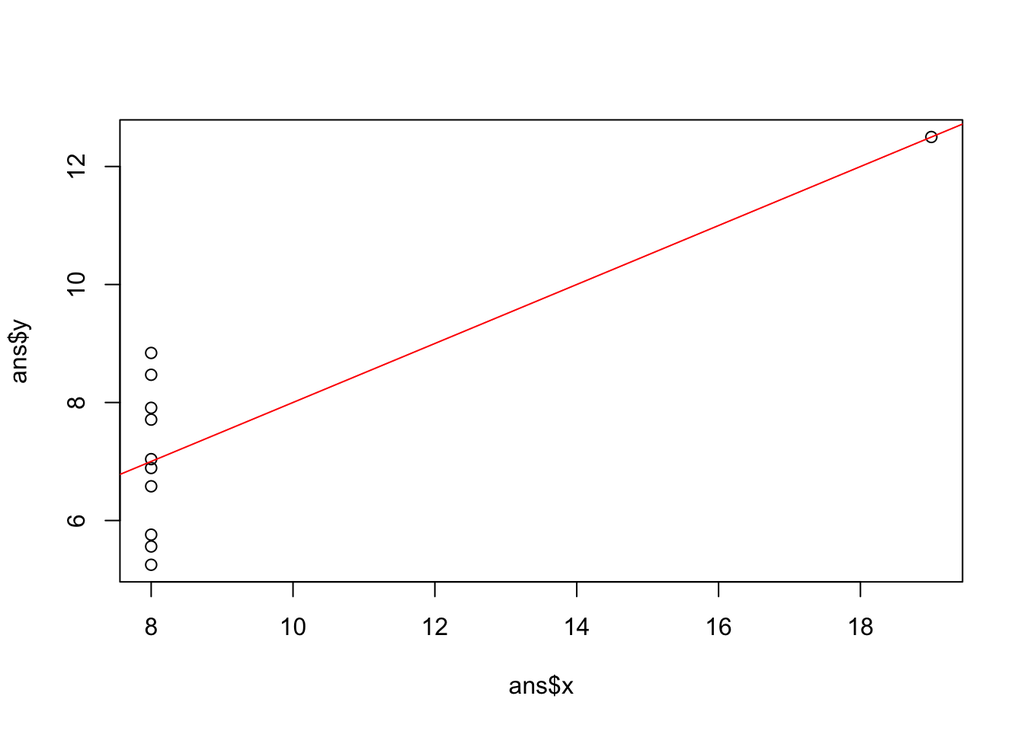

```
## Równanie prostej: y = 0.4999091x + 3.001727
```

```r
fit_models(ans4)
```

Krzysztof Stawarz